# Two-Dimensional PAWN Sensitivity Analysis

Sumit Jyoti

2026-09-08

# 1 Model parameters and analysis settings

The sensitivity analysis retains the two-dimensional structure of the main SD-DRM. The inner computational layer contains the three exposure-variability inputs and the two scenario inputs. Including resistant fraction and residual doxycycline concentration in this layer allows their specified ranges to be examined but does not imply that they represent real-world variability. Paired Emax-EC50 values form the outer pharmacodynamic-uncertainty layer.

```r
alpha <- 0.60; beta <- 1.31e6; tfs <- 1; MIC <- 0.13
C_min <- 75; C_max <- 1100; M_shape <- 0.8760928; M_scale <- 43.276368
F_min <- 0.0018; F_max <- 0.0233; fr_min <- 0; fr_max <- 0.5
pMIC_min <- 0; pMIC_max <- 10
n_outer <- 500; n <- 15; Nu <- 100; Nc <- 100
seed <- 123; pawn_seed <- 0; ncores <- 4
critval <- 1.36 * sqrt((Nu + Nc) / (Nu * Nc))
stopifnot(Nu == Nc, Nu <= n_outer)

exposure <- read.csv("raw_shrimp_mc2d_simulation_data.csv") |> arrange(inner_id)
exposure_names <- c("C_retail", "M", "F_pathogenic")
stopifnot(all(exposure_names %in% names(exposure)))
variability_inner <- exposure[, exposure_names]; n_inner <- nrow(variability_inner)
```

# 2 Pharmacodynamic uncertainty

Emax and EC50 are sampled together from their fitted bivariate normal distribution, expressed in the units used by the SD-DRM. When either parameter is conditioned, the other is sampled from its conditional normal distribution so their fitted relationship is preserved.

```r
pd_estimates <- c(Emax_per_day = 81.5877739, EC50_ug_mL = 0.166877)
pd_covariance <- matrix(c(32.631766203, 0.124149052, 0.124149052, 0.002101326), 2, 2,
                        byrow = TRUE, dimnames = list(names(pd_estimates), names(pd_estimates)))

rposnorm <- function(N, mean, sd) {
  x <- rnorm(N, mean, sd)
  while (any(x <= 0)) x[x <= 0] <- rnorm(sum(x <= 0), mean, sd)
  x
}

draw_pd <- function(N) {
  x <- MASS::mvrnorm(N, pd_estimates, pd_covariance)
  invalid <- x[, 1] <= 0 | x[, 2] <= 0
  while (any(invalid)) {
    x[invalid, ] <- MASS::mvrnorm(sum(invalid), pd_estimates, pd_covariance)
    invalid <- x[, 1] <= 0 | x[, 2] <= 0
  }
  data.frame(Emax_per_day = x[, 1], EC50_ug_mL = x[, 2])
}

draw_conditional_pd <- function(N, condition_on, value) {
  mu1 <- pd_estimates[1]; mu2 <- pd_estimates[2]
  v1 <- pd_covariance[1, 1]; v2 <- pd_covariance[2, 2]; cv <- pd_covariance[1, 2]

  if (condition_on == "Emax_per_day") {
    Emax <- rep(value, N)
    EC50 <- rposnorm(N, mu2 + cv / v1 * (value - mu1), sqrt(v2 - cv^2 / v1))
  } else if (condition_on == "EC50_ug_mL") {
    EC50 <- rep(value, N)
    Emax <- rposnorm(N, mu1 + cv / v2 * (value - mu2), sqrt(v1 - cv^2 / v2))
  } else stop("Unknown pharmacodynamic conditioning variable.")

  data.frame(Emax_per_day = Emax, EC50_ug_mL = EC50)
}

set.seed(seed); pd_outer <- draw_pd(n_outer)
```

# 3 PAWN design functions

PAWN compares an unconditional output CDF with CDFs obtained by conditioning each input at 15 interior quantiles. Each condition-specific effect is measured using the two-sample Kolmogorov-Smirnov distance.

```r
pawn_probs <- (seq_len(n) - 0.5) / n

make_design <- function(sample_inputs, input_names, condition_values, seed) {
  set.seed(seed); P <- length(input_names)
  unconditional <- sample_inputs(Nu); conditional <- sample_inputs(P * n * Nc)
  for (j in seq_len(P)) for (k in seq_len(n)) {
    idx <- ((j - 1) * n * Nc + (k - 1) * Nc + 1):((j - 1) * n * Nc + k * Nc)
    conditional[idx, input_names[j]] <- condition_values[[input_names[j]]][k]
  }
  list(unconditional = unconditional, conditional = conditional,
       input_names = input_names, condition_values = condition_values)
}

make_pd_design <- function(unconditional_pd, seed) {
  set.seed(seed); input_names <- c("Emax_per_day", "EC50_ug_mL")
  unconditional <- unconditional_pd[seq_len(Nu), , drop = FALSE]
  reference <- draw_pd(50000)
  condition_values <- lapply(reference[, input_names, drop = FALSE], quantile,
                             probs = pawn_probs, names = FALSE)
  conditional <- map_dfr(input_names, function(input) {
    map_dfr(condition_values[[input]], ~draw_conditional_pd(Nc, input, .x))
  })
  list(unconditional = unconditional, conditional = conditional,
       input_names = input_names, condition_values = condition_values)
}

calculate_ks <- function(y_u, y_c, input_names) {
  KS <- matrix(NA_real_, length(input_names), n,
               dimnames = list(input_names, paste0("Condition_", seq_len(n))))
  for (j in seq_along(input_names)) for (k in seq_len(n)) {
    idx <- ((j - 1) * n * Nc + (k - 1) * Nc + 1):((j - 1) * n * Nc + k * Nc)
    KS[j, k] <- unname(suppressWarnings(ks.test(y_u, y_c[idx], exact = FALSE)$statistic))
  }
  KS
}

parallel_lapply <- function(N, FUN) {
  if (ncores > 1 && .Platform$OS.type != "windows")
    parallel::mclapply(seq_len(N), FUN, mc.cores = ncores, mc.set.seed = FALSE)
  else lapply(seq_len(N), FUN)
}
```

# 4 Input designs

The exposure and scenario inputs use one common inner PAWN design. The scenario inputs are therefore treated like varying inputs computationally, while their scientific interpretation remains scenario-based. The same design is reused for all outer draws so differences are attributable to pharmacodynamic uncertainty rather than different random inner samples.

```r
sample_inner <- function(N) data.frame(
  C_retail = runif(N, C_min, C_max),
  M = rgamma(N, M_shape, scale = M_scale),
  F_pathogenic = runif(N, F_min, F_max),
  fr = runif(N, fr_min, fr_max),
  pMIC = runif(N, pMIC_min, pMIC_max)
)

inner_conditions <- list(
  C_retail = qunif(pawn_probs, C_min, C_max),
  M = qgamma(pawn_probs, M_shape, scale = M_scale),
  F_pathogenic = qunif(pawn_probs, F_min, F_max),
  fr = qunif(pawn_probs, fr_min, fr_max),
  pMIC = qunif(pawn_probs, pMIC_min, pMIC_max)
)

inner_names <- names(inner_conditions)
inner_design <- make_design(sample_inner, inner_names, inner_conditions, pawn_seed)
pd_design <- make_pd_design(pd_outer, pawn_seed + 1)

set.seed(pawn_seed + 2)
inner_reference <- transform(variability_inner,
                             fr = runif(n_inner, fr_min, fr_max),
                             pMIC = runif(n_inner, pMIC_min, pMIC_max))
```

# 5 SD-DRM evaluation

All model calculations remain on their original scales. The antibiotic lookup table covers every paired pharmacodynamic value required by the sensitivity analysis.

```r
pd_lookup_values <- bind_rows(pd_outer, pd_design$unconditional, pd_design$conditional)
ab_lookup <- make_ab_lookup(alpha = alpha, beta = beta,
                            Emax = pd_lookup_values$Emax_per_day,
                            EC50 = pd_lookup_values$EC50_ug_mL,
                            C_max = pMIC_max / 100 * MIC, tfs = tfs,
                            n_grid = 250, seed = pawn_seed, nsim = 1000)

event_risk <- function(x, Emax, EC50) {
  N <- nrow(x)
  calc_sd_drm(
    dose = x$C_retail * x$M * x$F_pathogenic, fr = x$fr,
    C = x$pMIC / 100 * MIC, alpha = alpha, beta = beta,
    Emax = rep(Emax, length.out = N), EC50 = rep(EC50, length.out = N),
    tfs = tfs, ab_lookup = ab_lookup
  )$risk_total
}
```

# 6 Inner-layer sensitivity with propagated uncertainty

For every paired outer Emax-EC50 draw, PAWN produces 15 KS distances for each inner input. At each conditioning value, the median across the 500 outer draws is retained. Consequently, every parameter contributes 15 plotted values, preserving its sensitivity pattern across the conditioning range while representing the typical effect across pharmacodynamic uncertainty.

```r
run_inner_outer <- function(u) {
  Emax <- pd_outer$Emax_per_day[u]; EC50 <- pd_outer$EC50_ug_mL[u]
  calculate_ks(event_risk(inner_design$unconditional, Emax, EC50),
               event_risk(inner_design$conditional, Emax, EC50), inner_names)
}

inner_ks <- simplify2array(parallel_lapply(n_outer, run_inner_outer))
dimnames(inner_ks) <- list(inner_names, paste0("Condition_", seq_len(n)),
                           paste0("Outer_", seq_len(n_outer)))
inner_condition_median <- apply(inner_ks, c(1, 2), median, na.rm = TRUE)
inner_condition_lower <- apply(inner_ks, c(1, 2), quantile, 0.025, na.rm = TRUE)
inner_condition_upper <- apply(inner_ks, c(1, 2), quantile, 0.975, na.rm = TRUE)
```

# 7 Pharmacodynamic uncertainty sensitivity

Emax and EC50 sensitivity is evaluated on expected illness risk after averaging over the same inner reference sample. The unconditional PAWN sample reuses the first 100 of the 500 propagated pairs; each conditional sample contains 100 pairs and preserves the fitted Emax-EC50 dependence.

```r
evaluate_pd <- function(data) unlist(parallel_lapply(nrow(data), function(i) {
  mean(event_risk(inner_reference, data$Emax_per_day[i], data$EC50_ug_mL[i]))
}), use.names = FALSE)

pd_ks <- calculate_ks(evaluate_pd(pd_design$unconditional),
                      evaluate_pd(pd_design$conditional), pd_design$input_names)
```

# 8 Sensitivity summaries

For each parameter, the median across its 15 condition-specific KS distances is the PAWN index. The remaining statistics describe how sensitivity changes across the conditioning range.

```r
parameter_labels <- c(C_retail = "C_retail", M = "M", F_pathogenic = "F_pathogenic",
                      fr = "f_r", pMIC = "pMIC", Emax_per_day = "Emax", EC50_ug_mL = "EC50")
component_map <- c(C_retail = "Exposure variability", M = "Exposure variability",
                   F_pathogenic = "Exposure variability", fr = "Scenario inputs",
                   pMIC = "Scenario inputs", Emax_per_day = "Pharmacodynamic uncertainty",
                   EC50_ug_mL = "Pharmacodynamic uncertainty")

summarise_ks <- function(x) {
  q <- t(apply(x, 1, quantile, c(0.025, 0.25, 0.50, 0.75, 0.975), na.rm = TRUE))
  data.frame(
    Component = unname(component_map[rownames(x)]),
    Parameter = unname(parameter_labels[rownames(x)]),
    Mean_KS = rowMeans(x, na.rm = TRUE), P2.5_KS = q[, 1], P25_KS = q[, 2],
    Median_PAWN = q[, 3], P75_KS = q[, 4], P97.5_KS = q[, 5],
    Minimum_KS = apply(x, 1, min, na.rm = TRUE), Maximum_KS = apply(x, 1, max, na.rm = TRUE)
  )
}

condition_matrix <- rbind(inner_condition_median, pd_ks)
pawn_summary <- summarise_ks(condition_matrix) |>
  mutate(Rank = rank(-Median_PAWN, ties.method = "min")) |>
  select(Component, Parameter, Rank, everything())

make_condition_table <- function(parameter, matrix, lower = NULL, upper = NULL,
                                 values, basis) data.frame(
  Component = unname(component_map[parameter]), Parameter = unname(parameter_labels[parameter]),
  Condition = seq_len(n), Conditioning_quantile = pawn_probs,
  Conditioning_value = values[[parameter]], Median_KS = matrix[parameter, ],
  P2.5_outer_KS = if (is.null(lower)) NA_real_ else lower[parameter, ],
  P97.5_outer_KS = if (is.null(upper)) NA_real_ else upper[parameter, ], Basis = basis
)

condition_summary <- bind_rows(
  map_dfr(inner_names, make_condition_table, matrix = inner_condition_median,
          lower = inner_condition_lower, upper = inner_condition_upper,
          values = inner_design$condition_values,
          basis = "Median and 95% range across paired PD outer draws"),
  map_dfr(pd_design$input_names, make_condition_table, matrix = pd_ks,
          values = pd_design$condition_values,
          basis = "KS distance after averaging over the inner reference sample")
)

dir.create("results", showWarnings = FALSE)
write.csv(pawn_summary, file.path("results", "pawn_2d_illness_risk_summary.csv"), row.names = FALSE)
write.csv(condition_summary, file.path("results", "pawn_condition_specific_ks.csv"), row.names = FALSE)
knitr::kable(pawn_summary, digits = 3,
             caption = "Two-dimensional PAWN sensitivity summary for illness risk")
```

Two-dimensional PAWN sensitivity summary for illness risk

|  | Component | Parameter | Rank | Mean_KS | P2.5_KS | P25_KS | Median_PAWN | P75_KS | P97.5_KS | Minimum_KS | Maximum_KS |
| --- | --- | --- | --- | --- | --- | --- | --- | --- | --- | --- | --- |
| C_retail | Exposure variability | C_retail | 3 | 0.184 | 0.090 | 0.130 | 0.18 | 0.190 | 0.379 | 0.09 | 0.41 |
| M | Exposure variability | M | 2 | 0.357 | 0.187 | 0.215 | 0.33 | 0.420 | 0.744 | 0.18 | 0.81 |
| F_pathogenic | Exposure variability | F_pathogenic | 3 | 0.195 | 0.094 | 0.145 | 0.18 | 0.245 | 0.361 | 0.09 | 0.41 |
| fr | Scenario inputs | f_r | 5 | 0.171 | 0.094 | 0.105 | 0.16 | 0.210 | 0.358 | 0.09 | 0.41 |
| pMIC | Scenario inputs | pMIC | 5 | 0.171 | 0.094 | 0.130 | 0.16 | 0.195 | 0.331 | 0.09 | 0.38 |
| Emax_per_day | Pharmacodynamic uncertainty | Emax | 7 | 0.139 | 0.070 | 0.095 | 0.14 | 0.175 | 0.233 | 0.07 | 0.25 |
| EC50_ug_mL | Pharmacodynamic uncertainty | EC50 | 1 | 0.581 | 0.327 | 0.410 | 0.55 | 0.715 | 0.922 | 0.32 | 0.96 |

# 9 Sensitivity figure

The single figure retains three panels for scientific interpretation. Each point is one of the 15 condition-specific KS distances and the box median is the PAWN index. Whiskers show the complete conditioning range.

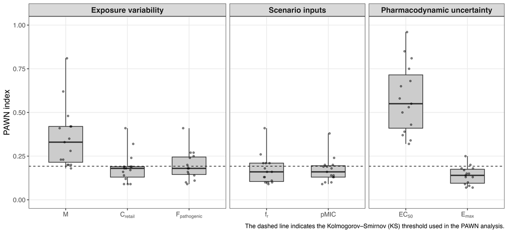

# 10 Analysis settings

```r
settings <- data.frame(
  Setting = c("Inner reference observations", "Outer PD simulations", "Conditioning values",
              "PAWN unconditional outputs", "Conditional outputs per condition", "KS reference value",
              "Exposure-variability inputs", "Scenario-range inputs",
              "Outer uncertainty inputs", "Emax-EC50 dependence", "Sensitivity output"),
  Value = c(n_inner, n_outer, n, Nu, Nc, round(critval, 4),
            "C_retail, M, and F_pathogenic", "f_r and pMIC",
            "Emax and EC50", "Preserved by paired and conditional sampling", "Illness risk")
)
knitr::kable(settings, caption = "Two-dimensional PAWN sensitivity-analysis settings")
```

Two-dimensional PAWN sensitivity-analysis settings

| Setting | Value |
| --- | --- |
| Inner reference observations | 1000 |
| Outer PD simulations | 500 |
| Conditioning values | 15 |
| PAWN unconditional outputs | 100 |
| Conditional outputs per condition | 100 |
| KS reference value | 0.1923 |
| Exposure-variability inputs | C_retail, M, and F_pathogenic |
| Scenario-range inputs | f_r and pMIC |
| Outer uncertainty inputs | Emax and EC50 |
| Emax-EC50 dependence | Preserved by paired and conditional sampling |
| Sensitivity output | Illness risk |